# Data Release Analysis

Janette Avelar

2023-03-22

# Q1: Which states are represented or not?

We had 3 unknowns in the data, which are resolved in the table and figure below.

```r
# ("N states in sample
# List of those not represented
# List (if any) U.S. territories represented")
#pull unique states
samp_states <- dat %>%
  select(school_id, school_state) %>%
  mutate(value = rep(1, 251)) %>%
  select(!school_id) %>%
  group_by(school_state) %>%
  summarize(N = sum(value)) %>%
  mutate(school_state = case_when(school_state == "" ~ "Unknown",
                                TRUE ~ as.character(school_state))) %>%
  rename(`State` = school_state)
#table
datatable(samp_states)
```

|  | State | N |
| --- | --- | --- |
| 1 | Alabama | 3 |
| 2 | Arizona | 12 |
| 3 | Arkansas | 4 |
| 4 | California | 21 |
| 5 | Colorado | 18 |
| 6 | Connecticut | 3 |
| 7 | Delaware | 1 |
| 8 | District of Columbia | 9 |
| 9 | Florida | 4 |
| 10 | Georgia | 7 |

[output cut: 32 more lines]

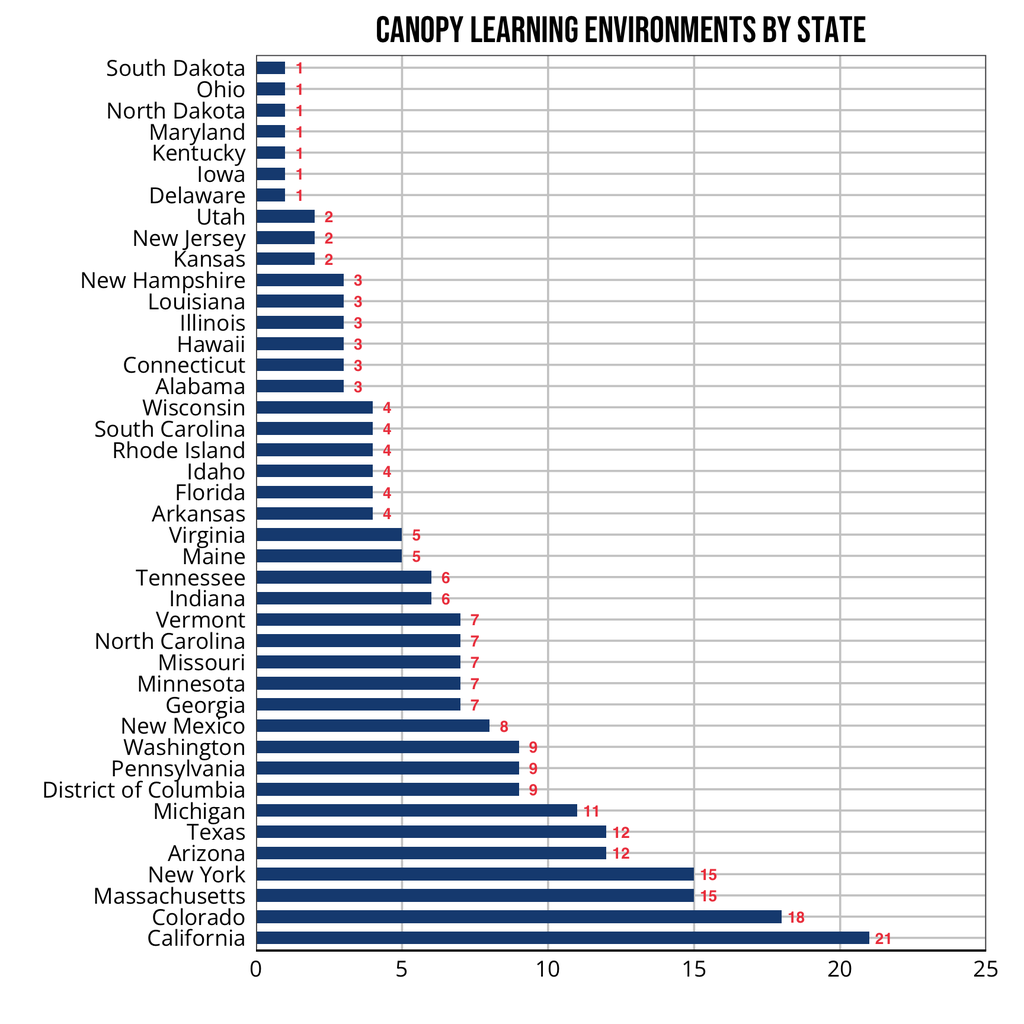

```r
#viz
plot_states <- samp_states %>%
  filter(!is.na(State)) %>%
ggplot(., aes(reorder(State, -N), N)) +
  geom_col(fill = transcend_cols[1]) +
  scale_y_continuous(limits=c(0, 25), expand = c(0,0)) +
  coord_flip() +
  labs(title = "Canopy Learning Environments by State",
       x = "",
       y = "") +
  geom_text(aes(label = signif(N)),
            nudge_y = .5,
            color = transcend_cols[3],
            fontface = "bold",
            size = 3.5,
            family = "sans")
plot_states
```

```r
# ggsave("finding-12a.png", plot = plot_states, path = here("final_products", "draft-findings"),
#        width = 12, height = 8, units = "in")
```

# Q2: What’s the breakdown of schools in the data by locale?

```r
locale <- dat %>%
  select(school_name, exclusive_locale) %>%
  mutate(rate = rep(1, 251)) %>%
  group_by(exclusive_locale) %>%
  summarize(N = sum(rate)) %>%
  rename(`Geographic Locale` = exclusive_locale)
#table
datatable(locale)
```

|  | Geographic Locale | N |
| --- | --- | --- |
| 1 | Multiple | 33 |
| 2 | Rural | 46 |
| 3 | Suburban | 31 |
| 4 | Urban | 141 |

```r
#viz
locale_plot <- locale %>%
  mutate(pct = N/251) %>%
ggplot(., aes(reorder(`Geographic Locale`, N), pct, fill = `Geographic Locale`)) +
  geom_col() +
  bar_y_scale_percent +
  theme(panel.grid.major.x = element_blank()) +
  scale_fill_manual(values = transcend_cols) +
  labs(title = "Canopy Learning Environments by Geographic Region",
       x = "",
       y = "") +
  theme(legend.position = "none") +
    geom_text(aes(label = scales::label_percent(accuracy = 1)(pct)),
            nudge_y = .01,
            vjust = 0,
            color = "black",
            fontface = "bold",
            size = 5,
            family = "sans")
ggsave("finding-11-V2.png", plot = locale_plot, path = here("final_products", "draft-findings"),
       width = 12, height = 8, units = "in")
```

## How do schools that identified as Other describe their locale?

```r
#others
locale_other <- dat %>%
  select(school_name, self_reported_locale_other_text) %>%
  filter(self_reported_locale_other_text != "") %>%
  rename("Self-identified locale" = self_reported_locale_other_text,
         "School Name" = school_name)
#table
datatable(locale_other)
```

|  | School Name | Self-identified locale |
| --- | --- | --- |
| 1 | AIM Academy | Our students travel from over 110 zip codes to go to our school. |
| 2 | Prospect Academy | We have students from 32 zip codes around the Denver metro area, including some rural places. |
| 3 | Oceti Sakowin Educational Learning Center | Reservation |
| 4 | Oxford Virtual Academy | We have students form across south east Michigan and a distant county. |
| 5 | SEEQS: the School for Examining Essential Questions of Sustainability | ""Urban"" Honolulu doesn't really align with what ""urban"" means in other districts, but it's the best matching description. |
| 6 | Gem Prep Nampa | Gem Prep: Nampa serves nearly twice the percentage of Latino students as the average Idaho school. |
| 7 | Digital Pioneers Academy | Most of our students who attend DPA lives in DC's Wards 7 and 8. |

Note that the numbers are slightly wonky if you read the descriptions that schools chose to include–though Gem Prep Nampa and SEEQS identified themselves as `Other`, what they disclosed does not actually categorize them differently. Thus, suburban should be 1 higher (N = 32 because of Gem Prep) and urban should be 1 higher (N = 142 because of SEEQS).

# Q3: What’s the breakdown of schools in the data by level?

```r
#(N schools across levels (elementary, middle, high))
level <- dat %>%
  select(starts_with("grades_")) %>%
  rename("Prekindergarten" = grades_prek,
         "Elementary" = grades_elementary,
         "Middle" = grades_middle,
         "High" = grades_high) %>%
  summarise(across(where(is.numeric), ~ sum(.x, na.rm = TRUE))) %>%
  pivot_longer(everything(),
               names_to = "School level",
               values_to = "N")
#table
datatable(level, rownames = FALSE)
```

| School level | N |
| --- | --- |
| Prekindergarten | 58 |
| Elementary | 114 |
| Middle | 102 |
| High | 147 |

```r
#factor viz data to reorder columns and generate percent
level <- level %>%
  mutate(`School level` = factor(`School level`,
                levels = c("Prekindergarten", "Elementary", "Middle", "High"),
                labels = c("Prekindergarten", "Elementary", "Middle", "High")),
         pct = N/251)
#Modified V2 plot - added subtitle, converted to pct from count, added pct labels
level_plot <-
ggplot(level, aes(`School level`, pct, fill = `School level`)) +
  geom_col() +
  scale_fill_manual(values = transcend_cols) +
  bar_y_scale_percent +
  theme(panel.grid.major.x = element_blank()) +
  labs(title = "Canopy Learning Environments by Level",
       subtitle = "Note: Some schools serve grades that cross levels, making our total percentage greater than 100%.",
       x = "",
       y = "") +
  theme(legend.position = "none") +
    geom_text(aes(label = scales::label_percent(accuracy = 1)(pct)),
            nudge_y = .01,
            vjust = 0,
            color = "black",
            fontface = "bold",
            size = 5,
            family = "sans")
ggsave("finding-1-V2.png", plot = level_plot, path = here("final_products", "draft-findings"),
       width = 12, height = 8, units = "in")
```

# Q4: What’s the breakdown of schools in the data by school type?

```r
#(N schools across school types (charter, district, independent))
# NOTE TO SELF TO MAKE A FUNCTION FROM THE ACTION BELOW
type <- dat %>%
  select(school_descriptor) %>%
  mutate(value = rep(1, 251),
         school_descriptor = case_when(
           school_descriptor == 1 ~ "Public district school",
           school_descriptor == 2 ~ "Public charter school",
           school_descriptor == 3 ~ "Independent (private) school"
         )) %>%
  group_by(school_descriptor) %>%
  summarize(N = sum(value)) %>%
  rename("School Type" = school_descriptor)
#table
datatable(type, rownames = FALSE)
```

| School Type | N |
| --- | --- |
| Independent (private) school | 36 |
| Public charter school | 102 |
| Public district school | 113 |

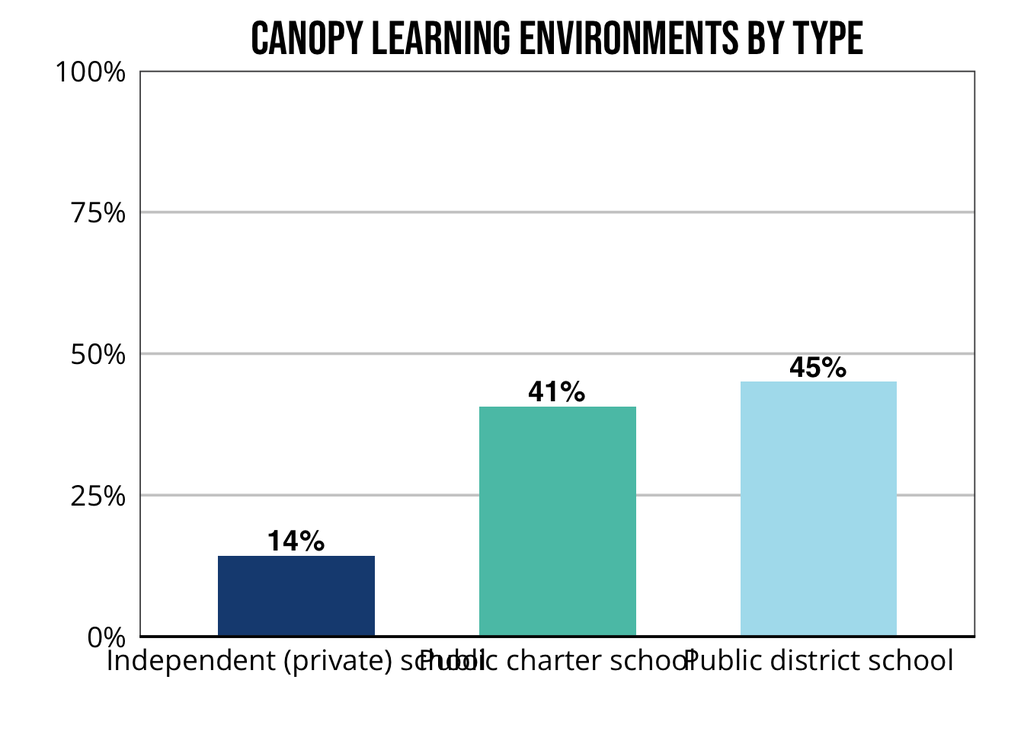

```r
#viz
#create viz data - add pct
type <- type %>%
  mutate(pct = N/251)

ggplot(type, aes(reorder(`School Type`, pct), pct, fill = `School Type`)) +
  geom_col() +
  scale_fill_manual(values = c(transcend_cols[1], transcend_cols[2], transcend_cols[4])) +
  bar_y_scale_percent +
  theme(panel.grid.major.x = element_blank()) +
  labs(title = "Canopy Learning Environments by Type",
       x = "",
       y = "") +
  theme(legend.position = "none") +
    geom_text(aes(label = scales::label_percent(accuracy = 1)(pct)),
            nudge_y = .01,
            vjust = 0,
            color = "black",
            fontface = "bold",
            size = 5,
            family = "sans")
```

```r
# ggsave("finding-2-V2.png", plot = type_plot, path = here("final_products", "draft-findings"),
#        width = 12, height = 8, units = "in")
```

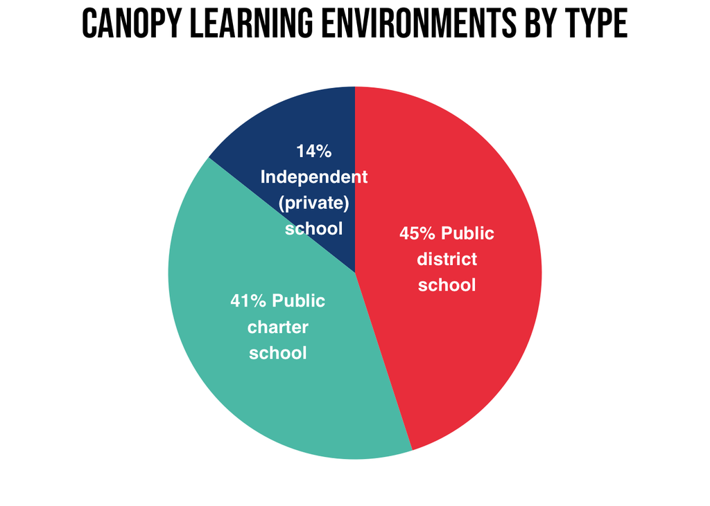

```r
 type_plot2 <-

#create pie chart
ggplot(type, aes(x = "", y = N, fill = `School Type`)) +
  geom_bar(stat = "identity", width = 1) +
  coord_polar("y", start = 0) +
  theme_void() +
  geom_text(aes(label = str_wrap(paste(label_percent(accuracy = 1)(pct), `School Type`, sep = "\n"), 10)),
            position = position_stack(vjust = .5),
            color = "white",
            fontface = "bold",
            size = 4.5,
            family = "sans") +
  scale_fill_manual(values = c(transcend_cols[1], transcend_cols[2], transcend_cols[3])) +
  theme(plot.title = element_text(family = "Bebas Neue",
                                  color = "black",
                                  size = 30,
                                  hjust = 0.5),
        legend.position = "none",
        text = element_text(size = 14,
                            family = "sans",
                            color = transcend_grays[1])) +
  labs(title = "Canopy Learning Environments by Type",
       x = "",
       y = "")
type_plot2
```

```r
ggsave("finding-2-V2.png", plot = type_plot2, path = here("final_products", "draft-findings"),
       width = 12, height = 8, units = "in")
```

# Q5: What’s the racial/ethnic breakdown of Canopy school leadership teams?

```r
#(Sample demographics - school leadership team)
lead_team <- dat %>%
  select(leadership_diversity) %>%
  mutate(value = rep(1, 251),
         leadership_diversity = case_when(
           leadership_diversity == 0 ~ "Prefer not to say",
           leadership_diversity == 1 ~ "0 - 24% people of color",
           leadership_diversity == 2 ~ "25 - 49% people of color",
           leadership_diversity == 3 ~ "50 - 74% people of color",
           leadership_diversity == 4 ~ "75 - 100% people of color",
           leadership_diversity == 5 ~ "Not sure"
         )) %>%
  group_by(leadership_diversity) %>%
  summarize(N = sum(value)) %>%
  rename("School Leadership Team Diversity" = leadership_diversity)
#table
datatable(lead_team, rownames = FALSE)
```

| School Leadership Team Diversity | N |
| --- | --- |
| 0 - 24% people of color | 103 |
| 25 - 49% people of color | 37 |
| 50 - 74% people of color | 53 |
| 75 - 100% people of color | 51 |
| Prefer not to say | 7 |

# Q6: What are the frequencies of all practices?

```r
#(N and % selected practices)
prac <- dat %>%
  select(starts_with("practices_")) %>%
  sapply(., as.numeric) %>%
  as.data.frame() %>%
  summarise(across(where(is.numeric), ~ sum(.x, na.rm = TRUE))) %>%
  pivot_longer(everything(),
               names_to = "Practice",
               values_to = "N") %>%
  group_by(Practice) %>%
  mutate(Pct = paste0(round(N/251*100, 2), "%"))
#table
datatable(prac)
```

|  | Practice | N | Pct |
| --- | --- | --- | --- |
| 1 | practices_a_la_carte | 30 | 11.95% |
| 2 | practices_accommodations | 164 | 65.34% |
| 3 | practices_adult_wellness | 105 | 41.83% |
| 4 | practices_advancement_mastery | 101 | 40.24% |
| 5 | practices_advisories | 154 | 61.35% |
| 6 | practices_all_courses_designed_for_inclusion | 183 | 72.91% |
| 7 | practices_anti_racist | 135 | 53.78% |
| 8 | practices_assessments_agency | 53 | 21.12% |
| 9 | practices_assessments_bilingual | 37 | 14.74% |
| 10 | practices_assessments_career | 96 | 38.25% |

[output cut: 63 more lines]

## How many practices did schools typically select?

Average over the whole sample is ~34 tags.

```r
avg_prac <- dat %>%
  select(school_id, starts_with("practices_")) %>%
  group_by(school_id) %>%
  mutate(sum_tag = rowSums(across(starts_with("practices_")))) %>%
  ungroup() %>%
  select(!starts_with("practices_")) %>%
  summarize(`Average N Tags Selected` = mean(sum_tag))
#table
datatable(avg_prac, rownames = FALSE)
```

| Average N Tags Selected |
| --- |
| 34.398406374502 |

# Q7: What are the frequencies of core practices?

```r
#(N and % core practices)
core_prac <- dat %>%
  select(starts_with("core_")) %>%
    summarise(across(where(is.numeric), ~ sum(.x, na.rm = TRUE))) %>%
  pivot_longer(everything(),
               names_to = "Core practice",
               values_to = "N") %>%
  group_by(`Core practice`) %>%
  mutate(Pct = paste0(round(N/251*100, 2), "%"))
#table
datatable(core_prac)
```

|  | Core practice | N | Pct |
| --- | --- | --- | --- |
| 1 | core_a_la_carte | 1 | 0.4% |
| 2 | core_accommodations | 31 | 12.35% |
| 3 | core_adult_wellness | 8 | 3.19% |
| 4 | core_advancement_mastery | 10 | 3.98% |
| 5 | core_advisories | 22 | 8.76% |
| 6 | core_all_courses_designed_for_inclusion | 39 | 15.54% |
| 7 | core_anti_racist | 23 | 9.16% |
| 8 | core_assessments_agency | 9 | 3.59% |
| 9 | core_assessments_bilingual | 1 | 0.4% |
| 10 | core_assessments_career | 5 | 1.99% |

[output cut: 63 more lines]

# Q8: How long have schools been implementing each core practice?

Note: This plot looks messy because it’s too large right now. Once we have clusters finalized I can create condensed plots by cluster, or alternately organize them in whichever ways makes most sense.

```r
#(N and % implementation time)
time_prac <- dat %>%
  select(starts_with("time_")) %>%
    pivot_longer(everything(),
               names_to = "Practice",
               values_to = "N") %>%
  mutate(`Less than a year` = case_when(N == 1 ~ 1, TRUE ~ 0),
         `1-2 years` = case_when(N == 2 ~ 1, TRUE ~ 0),
         `3-4 years` = case_when(N == 3 ~ 1, TRUE ~ 0),
         `5+ years` = case_when(N == 4 ~ 1, TRUE ~ 0),
         Practice = sub("time_", "practices_", Practice)) %>%
  select(!N) %>%
  group_by(Practice) %>%
  summarise(across(where(is.numeric), ~ sum(.x, na.rm = TRUE)))
#table
datatable(time_prac)
```

|  | Practice | Less than a year | 1-2 years | 3-4 years | 5+ years |
| --- | --- | --- | --- | --- | --- |
| 1 | practices_a_la_carte | 0 | 1 | 0 | 0 |
| 2 | practices_accommodations | 2 | 0 | 5 | 24 |
| 3 | practices_adult_wellness | 1 | 1 | 2 | 3 |
| 4 | practices_advancement_mastery | 1 | 0 | 3 | 6 |
| 5 | practices_advisories | 2 | 5 | 0 | 15 |
| 6 | practices_all_courses_designed_for_inclusion | 3 | 5 | 6 | 25 |
| 7 | practices_anti_racist | 0 | 4 | 7 | 12 |
| 8 | practices_assessments_agency | 0 | 1 | 2 | 6 |
| 9 | practices_assessments_bilingual | 0 | 0 | 0 | 1 |
| 10 | practices_assessments_career | 0 | 0 | 2 | 3 |

[output cut: 63 more lines]

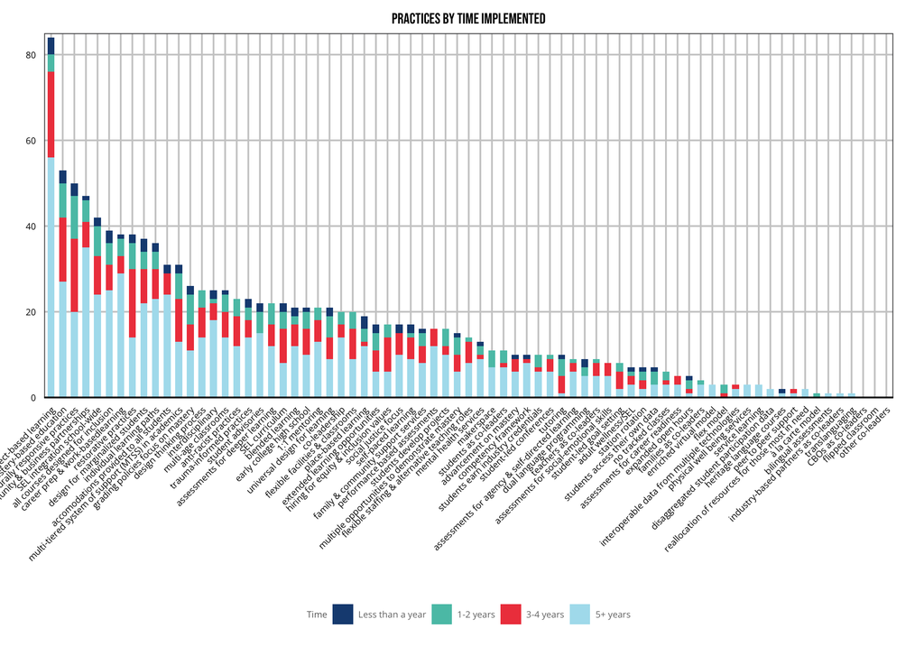

```r
#viz
#need long format?
plot_time_prac <- time_prac %>%
  pivot_longer(cols = c(`Less than a year`, `1-2 years`, `3-4 years`, `5+ years`),
               names_to = "Time",
               values_to = "N") %>%
  mutate(Time = factor(Time, levels = c(
    "Less than a year",
    "1-2 years",
    "3-4 years",
    "5+ years"
  )))
ggplot(plot_time_prac, aes(reorder(Practice, -N), N, fill = Time)) +
  geom_col() +
  scale_fill_manual(values = transcend_cols) +
  scale_y_continuous(limits=c(0, 85), expand = c(0,0)) +
  labs(title = "Practices by Time Implemented",
       x = "",
       y = "") +
  scale_x_discrete(labels = label_tags()) +
  theme(legend.position = "bottom",
        legend.direction = "horizontal",
        text = element_text(size = 7),
        axis.text.x = element_text(angle = 45, hjust = 1))
```

```r
###plan to facet by cluster once cluster analysis presented
```

## Top 10

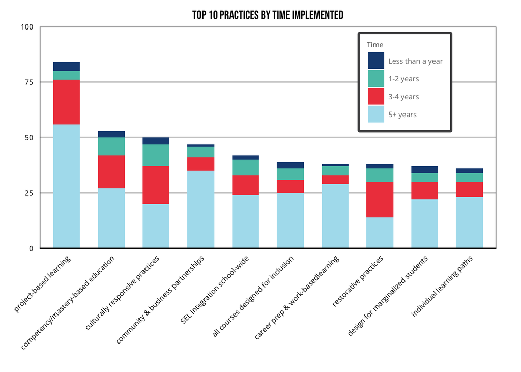

```r
top_prac <-
  plot_time_prac %>%
  group_by(Practice) %>%
  mutate(sum = sum(N),
         pct = N/sum,
         tot_pct = round(sum/251*100, 0)) %>%
  ungroup() %>%
  group_by(Practice, Time) %>%
  arrange(desc(sum)) %>%
  ungroup() %>%
  slice_head(., n = 40) %>%
  ggplot(., aes(reorder(Practice, -sum), N, fill = Time)) +
  geom_col() +
  theme(panel.grid.major.x = element_blank()) +
  scale_fill_manual(values = transcend_cols) +
  scale_y_continuous(limits=c(0, 100), expand = c(0,0)) +
  labs(title = "Top 10 Practices by Time Implemented",
       x = "",
       y = "") +
  scale_x_discrete(labels = label_tags()) +
  theme(legend.position = c(.8,.75),
        legend.box.background = element_rect(color = transcend_grays[1], linewidth = 2),
        text = element_text(size = 7),
        axis.text.x = element_text(angle = 45, hjust = 1)
        )
    # geom_text(aes(label = scales::label_percent(accuracy = 1)(tot_pct)),
    #         nudge_y = .01,
    #         vjust = 0,
    #         color = transcend_cols[3],
    #         fontface = "bold",
    #         size = 5,
    #         family = "sans")
top_prac
```

```r
ggsave("finding-8a-V2.png", plot = top_prac, path = here("final_products", "draft-findings"),
       width = 8, height = 6, units = "in")
```

Alternate view

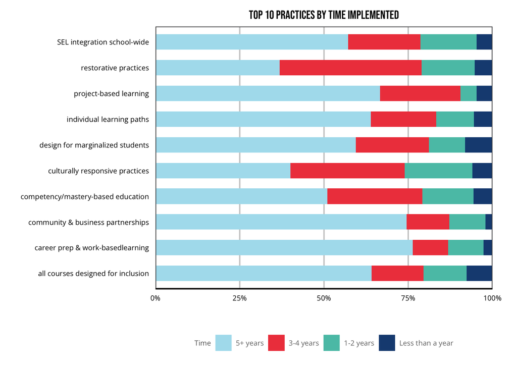

```r
top_prac2 <-
  plot_time_prac %>%
  group_by(Practice) %>%
  mutate(sum = sum(N),
         pct = N/sum) %>%
  ungroup() %>%
  group_by(Practice, Time) %>%
  arrange(desc(sum)) %>%
  ungroup() %>%
  slice_head(., n = 40) %>%
  ggplot(., aes(Practice, pct, fill = Time)) +
  geom_col() +
  bar_y_scale_percent +
  theme(panel.grid.major.y = element_blank()) +
  scale_fill_manual(values = transcend_cols) +
  coord_flip() +
  #scale_y_continuous(limits=c(0, 100), expand = c(0,0)) +
  labs(title = "Top 10 Practices by Time Implemented",
       x = "",
       y = "") +
  scale_x_discrete(labels = label_tags()) +
  theme(legend.position = "bottom",
        legend.direction = "horizontal",
        text = element_text(size = 7)) +
  guides(fill = guide_legend(reverse = TRUE))
    # geom_text(aes(y = Practice, label = signif(sum)),
    #         #nudge_y = .5,
    #         color = transcend_cols[3],
    #         fontface = "bold",
    #         size = 5,
    #         family = "sans")
top_prac2
```

```r
ggsave("finding-8b-V2.png", plot = top_prac2, path = here("final_products", "draft-findings"),
       width = 8, height = 6, units = "in")
```

# Q9: Which core practices have been implemented most since AY20

i.e., What did schools start implementing post-COVID?

This left us with 27 practices with the following `Top 5`: * Project-based learning (N = 20)  
* Culturally responsive practices (N = 17)  
* Restorative practices (N = 16)  
* Competency based education (N = 15)  
* Multi-tiered systems of support (N = 10)

For reference, a total of 214 schools indicated these practices were core practices implemented 3-4 years (i.e., percentage is pulled from total schools that selected a tag and indicated implementing 3-4 years ago, rather than the total number of schools N = 251).

```r
covid_core <- time_prac %>%
  select(!c(`Less than a year`, `5+ years`, `1-2 years`)) %>%
  filter(`3-4 years` > 4) %>%
  mutate(Pct = paste0(round(`3-4 years`/sum(`3-4 years`)*100, 2), "%"))
#table
datatable(covid_core)
```

|  | Practice | 3-4 years | Pct |
| --- | --- | --- | --- |
| 1 | practices_accommodations | 5 | 2.34% |
| 2 | practices_all_courses_designed_for_inclusion | 6 | 2.8% |
| 3 | practices_anti_racist | 7 | 3.27% |
| 4 | practices_assessments_deeper | 5 | 2.34% |
| 5 | practices_blended_learning | 5 | 2.34% |
| 6 | practices_community_partnerships | 6 | 2.8% |
| 7 | practices_competency_education | 15 | 7.01% |
| 8 | practices_culturally_responsive | 17 | 7.94% |
| 9 | practices_design_marginalized | 8 | 3.74% |
| 10 | practices_design_thinking | 7 | 3.27% |

[output cut: 17 more lines]

#testing branding

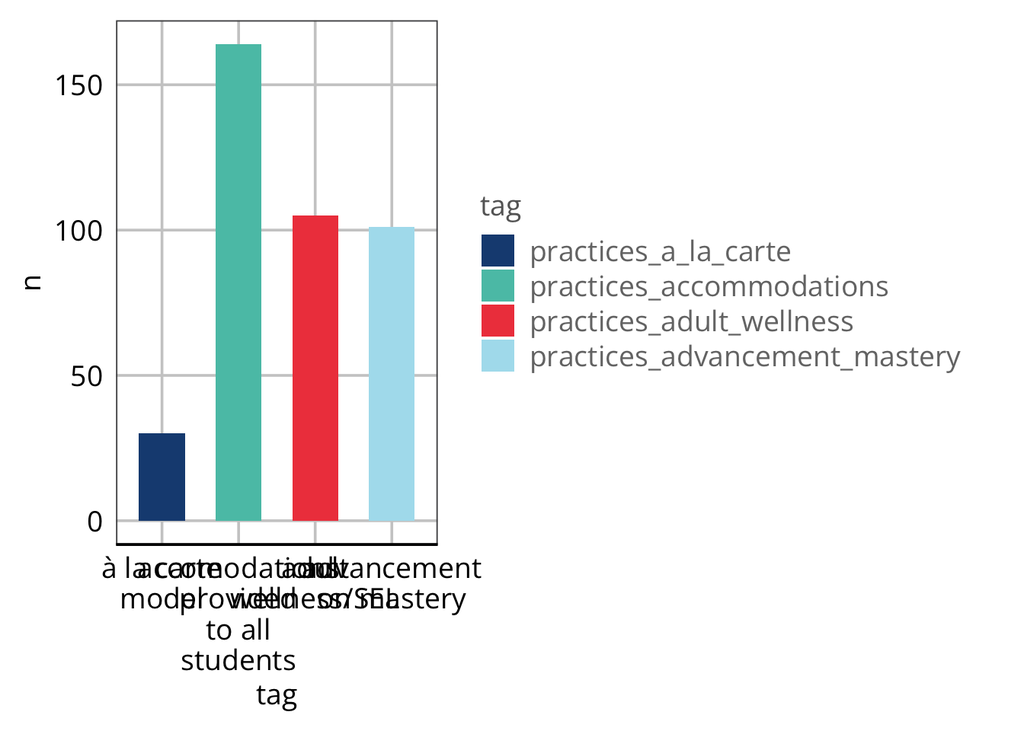

```r
tag_bar <- tags %>%
  select(school_id, starts_with("practices_")) %>%
  pivot_longer(cols = starts_with("practices_"),
               names_to = "tag",
               values_to = "selected") %>%
  group_by(tag) %>%
  summarize(n = sum(selected)) %>%
  head(n = 4)

ggplot(tag_bar, aes(x = tag, y = n, fill = tag)) +
  geom_col() +
  scale_x_discrete(labels = label_tags(wrap = 10)) +
  scale_fill_manual(values = transcend_cols)
```

#Misc. - Ignore

##Descriptors

```r
# desc <- full %>%
#   select(school_name, school_descriptor, school_descriptor_homeschool, school_descriptor_hybrid, school_descriptor_microschool, school_descriptor_sws, school_descriptor_virtual) %>%
#   mutate(school_type = case_when(
#     school_descriptor == 1 ~ "Public district school",
#            school_descriptor == 2 ~ "Public charter school",
#            school_descriptor == 3 ~ "Independent (private) school"),
#     school_description = case_when(
#       school_descriptor_homeschool == 1 ~ "Homeschool",
#       school_descriptor_hybrid == 1 ~ "Hybrid",
#       school_descriptor_microschool == 1 ~ "Microschool",
#       school_descriptor_sws == 1 ~ "School within school",
#       school_descriptor_virtual == 1 ~ "Virtual"
#     )) %>%
#   select(-c(starts_with("school_descriptor"), school_name)) %>%
#   mutate(rate = rep(1, 251)) %>%
#   group_by(school_type, school_description) %>%
#   summarize(n = sum(rate)) %>%
#   ungroup() %>%
#   mutate(pct = n/)
```

```r
# lang_schools <- dat %>%
#   select(school_name, school_id, practices_dual_language, practices_translanguaging, practices_heritage_language, practices_assessments_bilingual, student_experience) %>%
#   filter(practices_dual_language == 1 |
#          practices_translanguaging == 1 |
#            practices_heritage_language == 1 |
#            practices_assessments_bilingual == 1)
# export(lang_schools, "language.csv")
```